# Correlation and Regression Demonstration

Clare Kimock

February 13, 2015

### Gordon et al. 2008 - The *Homo floresiensis* cranium (LB1): Size, scaling and early *Homo* affinities

#### First, read in the data:

```r
Howell <- read.csv("http://hompal-stats.wabarr.com/datasets/Howell_craniometry.csv", header = TRUE, na.strings = 0)
head(Howell)
```

```
##   ID Sex PopNum Population GOL NOL BNL BBH XCB XFB ZYB AUB WCB ASB BPL NPH
## 1  1   M      1      NORSE 189 185 100 135 143 120 133 119  70 112  96  66
## 2  2   M      1      NORSE 182 178 102 139 145 120 137 125  66 113 108  64
## 3  3   M      1      NORSE 191 187 102 123 140 114 134 125  74 112 102  67
## 4  4   M      1      NORSE 191 188 100 127 141 123 135 127  71 113  95  76
## 5  5   M      1      NORSE 178 177  97 128 138 117 129 121  69 111  90  67
## 6  6   M      1      NORSE 194 191 106 132 139 118 136 128  76 112 102  69
##   NLH JUB NLB MAB MDH MDB OBH OBB DKB NDS  WNB SIS ZMB SSS FMB NAS EKB DKS
## 1  50 118  26  63  31  13  31  42  22  12  9.5 4.9  83  20 100  19 100   8
## 2  48 118  25  72  19  13  28  39  21   9 10.8 4.5 101  27  95  17  96   9
## 3  53 112  23  65  28  14  33  41  20  13  8.1 4.5  90  24  98  19  97  10
## 4  53 114  26  62  25  12  35  40  23  10  8.8 4.4  94  23  98  16  99   8
## 5  51 115  24  64  26  14  32  39  21  11  8.9 5.4  91  21  96  18  97  10
## 6  50 117  25  65  29  13  33  40  22  13  8.3 2.8  91  22 101  20  98  11
##   IML XML MLS WMH SOS GLS STB FRC FRS FRF PAC PAS PAF OCC OCS OCF FOL NAR
```

[output cut: 20 more lines]

Since we are only interested in a few of the measurements in the dataset, we can create a new dataframe that includes only the relevant data:

```r
library(dplyr)
Howell <- tbl_df(Howell)

Howell.Selected <- select(Howell, ID:Population, GOL, BBH, XCB, BNL, BPL, ASB)

head(Howell.Selected)
```

```
## Source: local data frame [6 x 10]
##
##   ID Sex PopNum Population GOL BBH XCB BNL BPL ASB
## 1  1   M      1      NORSE 189 135 143 100  96 112
## 2  2   M      1      NORSE 182 139 145 102 108 113
## 3  3   M      1      NORSE 191 123 140 102 102 112
## 4  4   M      1      NORSE 191 127 141 100  95 113
## 5  5   M      1      NORSE 178 128 138  97  90 111
## 6  6   M      1      NORSE 194 132 139 106 102 112
```

Next, we need to read in the fossil craniometric data used in the paper:

```r
Fossil <- read.csv("http://hompal-stats.wabarr.com/datasets/Gordon_2008_cranial.csv", header = TRUE)
head(Fossil)
```

```
##      Specimen         Species GOL BBH XCB BNL BPL ASB
## 1         LB1 H. floresiensis 143  89 113  81  88  97
## 2  KNM-ER 406       P. boisei 163 103 144 109 135  94
## 3        OH 5       P. boisei 173  98 142 113 137  89
## 4       Sts 5    A. africanus 146 101 111  99 127  90
## 5 KNM-ER 1813      H. habilis 149  90 113  84 105  90
## 6       OH 24      H. habilis 145  89 120  71  92  90
```

#### Next, calculate the geometric mean for each individual in both datasets:

Recall from Homework #2:

```r
geomean <- function(x, na.rm = TRUE) {
  product <- prod(x, na.rm = TRUE)
  n <- sum(!is.na(x))
  Geomean <- product ^ (1/n)
  Geomean
  }
```

Now we can calculate the geometric mean of the six cranial measurements of interest for each specimen in the Howell dataset:

```r
Howell.Geomean <- numeric(nrow(Howell.Selected))

for(i in 1:nrow(Howell)) {Howell.Row.Geomean <- (geomean(Howell.Selected[i, -(1:4)]))
Howell.Geomean[i] <- Howell.Row.Geomean
}

head(Howell.Geomean)
```

```
## [1] 125.5847 128.8030 125.0972 124.2061 120.4040 127.5711
```

And then we can add it to the Howell.Selected dataframe:

```r
Howell.Selected$Geomean <- Howell.Geomean
head(Howell.Selected)
```

```
## Source: local data frame [6 x 11]
##
##   ID Sex PopNum Population GOL BBH XCB BNL BPL ASB  Geomean
## 1  1   M      1      NORSE 189 135 143 100  96 112 125.5847
## 2  2   M      1      NORSE 182 139 145 102 108 113 128.8030
## 3  3   M      1      NORSE 191 123 140 102 102 112 125.0972
## 4  4   M      1      NORSE 191 127 141 100  95 113 124.2061
## 5  5   M      1      NORSE 178 128 138  97  90 111 120.4040
## 6  6   M      1      NORSE 194 132 139 106 102 112 127.5711
```

We can do the same for the fossils:

```r
Fossil.Geomean <- numeric(nrow(Fossil))

for(i in 1:nrow(Fossil)) {Fossil.Row.Geomean <- (geomean(Fossil[i, -(1:2)]))
Fossil.Geomean[i] <- Fossil.Row.Geomean
}

head(Fossil.Geomean)
```

```
## [1]  99.90579 122.28670 122.12135 110.81871 103.12637  98.44749
```

And add a geometric mean column to the Fossil dataframe as well:

```r
Fossil$Geomean <- Fossil.Geomean
head(Fossil)
```

```
##      Specimen         Species GOL BBH XCB BNL BPL ASB   Geomean
## 1         LB1 H. floresiensis 143  89 113  81  88  97  99.90579
## 2  KNM-ER 406       P. boisei 163 103 144 109 135  94 122.28670
## 3        OH 5       P. boisei 173  98 142 113 137  89 122.12135
## 4       Sts 5    A. africanus 146 101 111  99 127  90 110.81871
## 5 KNM-ER 1813      H. habilis 149  90 113  84 105  90 103.12637
## 6       OH 24      H. habilis 145  89 120  71  92  90  98.44749
```

#### Make the Plots

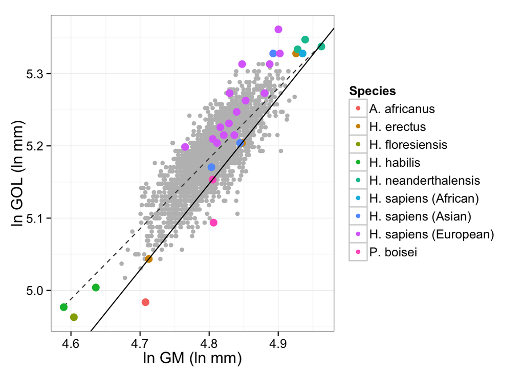

```r
library(ggplot2)

#library(lmodel2)

GOL_y <- c(log(Fossil$GOL[7]), log(Fossil$GOL[8]))

x <- c(log(Fossil$Geomean[7]), log(Fossil$Geomean[8]))

GOL_Slope <- (GOL_y[2] - GOL_y[1]) / (x[2] - x[1])

GOL_Intercept <- GOL_y[2] - (GOL_Slope*(x[2]))

GOL_Plot <- ggplot(data = Howell.Selected, aes(x = log(Geomean), y = log(GOL))) + geom_point(color = "gray") + labs(x = "ln GM (ln mm)", y = "ln GOL (ln mm)")  + geom_smooth(method=lm, se = FALSE, color = "gray28", linetype = 2, fullrange = TRUE) + geom_point(inherit.aes = FALSE, data = Fossil, aes(x = log(Geomean), y = log(GOL), color = Species, size = 10)) + geom_abline(intercept = GOL_Intercept, slope = GOL_Slope) + theme_bw(15) + guides(size = FALSE)

GOL_Plot
```

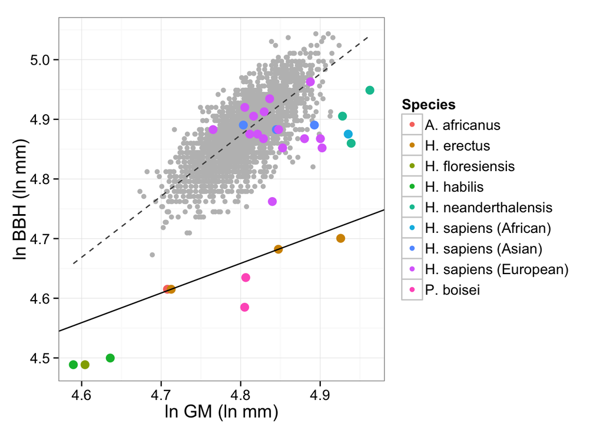

```r
BBH_y <- c(log(Fossil$BBH[7]), log(Fossil$BBH[8]))

x <- c(log(Fossil$Geomean[7]), log(Fossil$Geomean[8]))

BBH_Slope <- (BBH_y[2] - BBH_y[1]) / (x[2] - x[1])

BBH_Intercept <- BBH_y[2] - (BBH_Slope*(x[2]))

BBH_Plot <- ggplot(data = Howell.Selected, aes(x = log(Geomean), y = log(BBH))) + geom_point(color = "gray") + labs(x = "ln GM (ln mm)", y = "ln BBH (ln mm)")  + geom_smooth(method=lm, se = FALSE, color = "gray28", linetype = 2, fullrange = TRUE) + geom_point(inherit.aes = FALSE, data = Fossil, aes(x = log(Geomean), y = log(BBH), color = Species, size = 10)) + geom_abline(intercept = BBH_Intercept, slope = BBH_Slope) + theme_bw(15) + guides(size = FALSE)

BBH_Plot
```

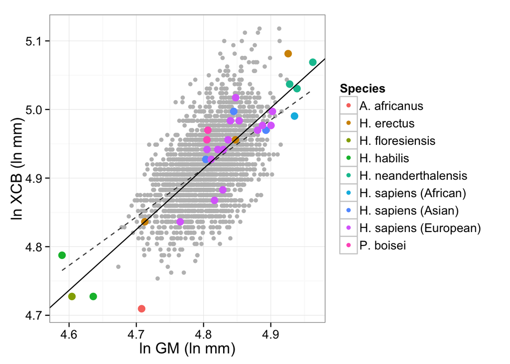

```r
XCB_y <- c(log(Fossil$XCB[7]), log(Fossil$XCB[8]))

x <- c(log(Fossil$Geomean[7]), log(Fossil$Geomean[8]))

XCB_Slope <- (XCB_y[2] - XCB_y[1]) / (x[2] - x[1])

XCB_Intercept <- XCB_y[2] - (XCB_Slope*(x[2]))

XCB_Plot <- ggplot(data = Howell.Selected, aes(x = log(Geomean), y = log(XCB))) + geom_point(color = "gray") + labs(x = "ln GM (ln mm)", y = "ln XCB (ln mm)")  + geom_smooth(method=lm, se = FALSE, color = "gray28", linetype = 2, fullrange = TRUE) + geom_point(inherit.aes = FALSE, data = Fossil, aes(x = log(Geomean), y = log(XCB), color = Species, size = 10)) + geom_abline(intercept = XCB_Intercept, slope = XCB_Slope) + theme_bw(15) + guides(size = FALSE)

XCB_Plot
```

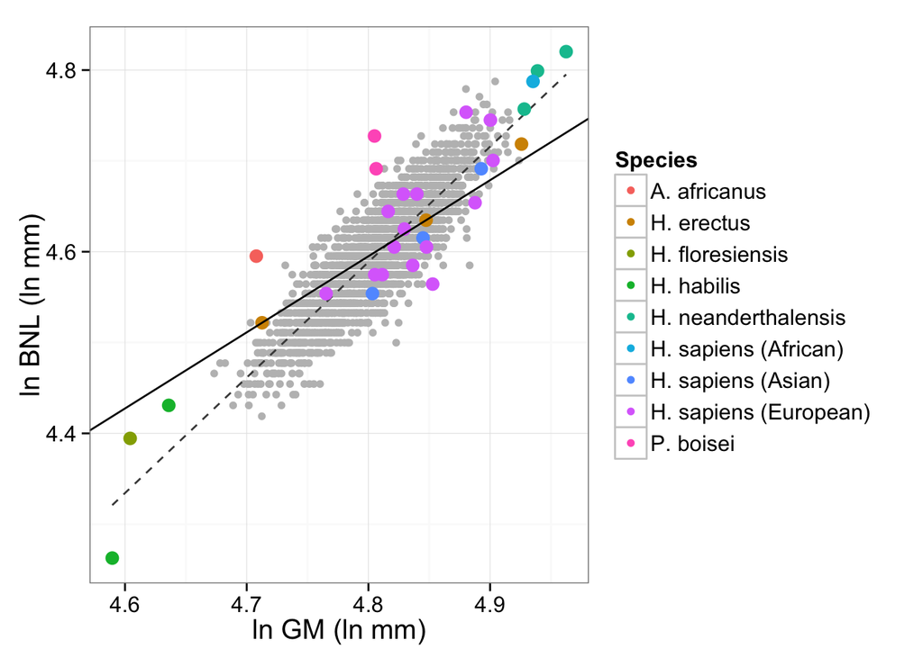

```r
BNL_y <- c(log(Fossil$BNL[7]), log(Fossil$BNL[8]))

x <- c(log(Fossil$Geomean[7]), log(Fossil$Geomean[8]))

BNL_Slope <- (BNL_y[2] - BNL_y[1]) / (x[2] - x[1])

BNL_Intercept <- BNL_y[2] - (BNL_Slope*(x[2]))

BNL_Plot <- ggplot(data = Howell.Selected, aes(x = log(Geomean), y = log(BNL))) + geom_point(color = "gray") + labs(x = "ln GM (ln mm)", y = "ln BNL (ln mm)")  + geom_smooth(method=lm, se = FALSE, color = "gray28", linetype = 2, fullrange = TRUE) + geom_point(inherit.aes = FALSE, data = Fossil, aes(x = log(Geomean), y = log(BNL), color = Species, size = 10)) + geom_abline(intercept = BNL_Intercept, slope = BNL_Slope) + theme_bw(15) + guides(size = FALSE)

BNL_Plot
```

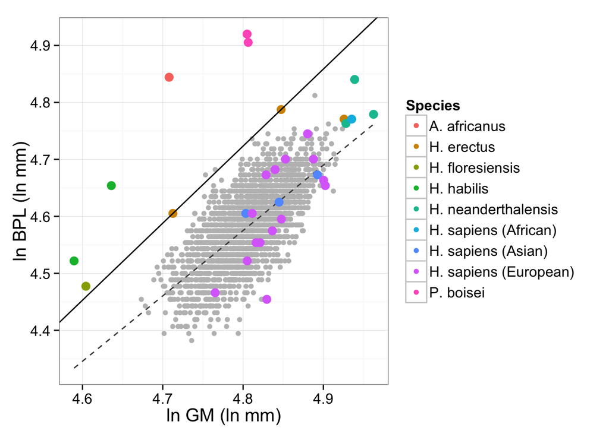

```r
BPL_y <- c(log(Fossil$BPL[7]), log(Fossil$BPL[8]))

x <- c(log(Fossil$Geomean[7]), log(Fossil$Geomean[8]))

BPL_Slope <- (BPL_y[2] - BPL_y[1]) / (x[2] - x[1])

BPL_Intercept <- BPL_y[2] - (BPL_Slope*(x[2]))

BPL_Plot <- ggplot(data = Howell.Selected, aes(x = log(Geomean), y = log(BPL))) + geom_point(color = "gray") + labs(x = "ln GM (ln mm)", y = "ln BPL (ln mm)")  + geom_smooth(method=lm, se = FALSE, color = "gray28", linetype = 2, fullrange = TRUE) + geom_point(inherit.aes = FALSE, data = Fossil, aes(x = log(Geomean), y = log(BPL), color = Species, size = 10)) + geom_abline(intercept = BPL_Intercept, slope = BPL_Slope) + theme_bw(15) + guides(size = FALSE)

BPL_Plot
```

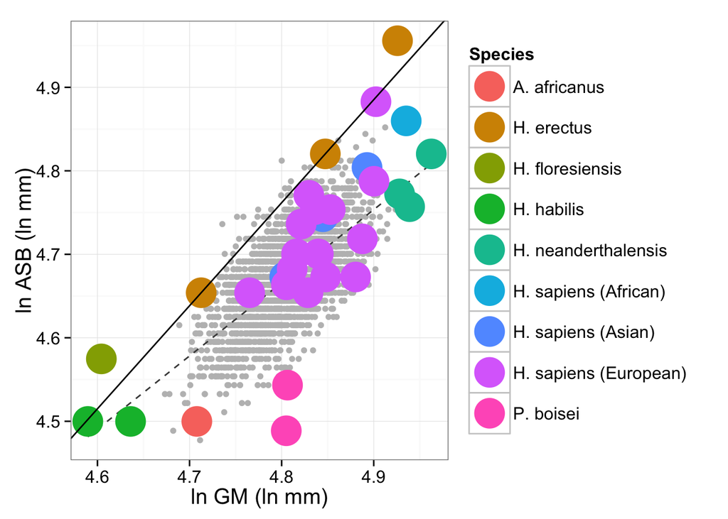

```r
ASB_y <- c(log(Fossil$ASB[7]), log(Fossil$ASB[8]))

x <- c(log(Fossil$Geomean[7]), log(Fossil$Geomean[8]))

ASB_Slope <- (ASB_y[2] - ASB_y[1]) / (x[2] - x[1])

ASB_Intercept <- ASB_y[2] - (ASB_Slope*(x[2]))

ASB_Plot <- ggplot(data = Howell.Selected, aes(x = log(Geomean), y = log(ASB))) + geom_point(color = "gray") + labs(x = "ln GM (ln mm)", y = "ln ASB (ln mm)")  + geom_smooth(method=lm, se = FALSE, color = "gray28", linetype = 2, fullrange = TRUE) + geom_point(inherit.aes = FALSE, data = Fossil, aes(x = log(Geomean), y = log(ASB), color = Species), size=10) + geom_abline(intercept = ASB_Intercept, slope = ASB_Slope) + theme_bw(15)

ASB_Plot
```

#### Do the analysis

In R, the function for linear regression is: lm()

This function is used to fit linear models, and takes several arguments: lm(formula = , data = , subset = , weights = , na.action, = , method = “qr”, model = TRUE, x = FALSE, y = FALSE, qr = TRUE, singular.ok = TRUE, contrasts = NULL, offset, ….)

##### To do the first regression: ln GM and ln GOL:

```r
GOL.Regression <- lm(data = Howell.Selected, log(Howell.Selected$GOL) ~ log(Howell.Selected$Geomean))

summary(GOL.Regression)
```

```
##
## Call:
## lm(formula = log(Howell.Selected$GOL) ~ log(Howell.Selected$Geomean),
##     data = Howell.Selected)
##
## Residuals:
##       Min        1Q    Median        3Q       Max
## -0.116482 -0.018854  0.000729  0.019155  0.087024
##
## Coefficients:
##                              Estimate Std. Error t value Pr(>|t|)
## (Intercept)                   0.51095    0.06611   7.729 1.56e-14 ***
## log(Howell.Selected$Geomean)  0.97325    0.01376  70.734  < 2e-16 ***
## ---
## Signif. codes:  0 '***' 0.001 '**' 0.01 '*' 0.05 '.' 0.1 ' ' 1
##
## Residual standard error: 0.02768 on 2522 degrees of freedom
## Multiple R-squared:  0.6649, Adjusted R-squared:  0.6647
## F-statistic:  5003 on 1 and 2522 DF,  p-value: < 2.2e-16
```

##### Now, ln GM and ln BBH:

```r
BBH.Regression <- lm(data = Howell.Selected, log(Howell.Selected$BBH) ~ log(Howell.Selected$Geomean))

summary(BBH.Regression)
```

```
##
## Call:
## lm(formula = log(Howell.Selected$BBH) ~ log(Howell.Selected$Geomean),
##     data = Howell.Selected)
##
## Residuals:
##       Min        1Q    Median        3Q       Max
## -0.146617 -0.022905  0.001303  0.025667  0.117008
##
## Coefficients:
##                              Estimate Std. Error t value Pr(>|t|)
## (Intercept)                  -0.04479    0.08724  -0.513    0.608
## log(Howell.Selected$Geomean)  1.02469    0.01816  56.438   <2e-16 ***
## ---
## Signif. codes:  0 '***' 0.001 '**' 0.01 '*' 0.05 '.' 0.1 ' ' 1
##
## Residual standard error: 0.03653 on 2522 degrees of freedom
## Multiple R-squared:  0.5581, Adjusted R-squared:  0.5579
## F-statistic:  3185 on 1 and 2522 DF,  p-value: < 2.2e-16
```

##### Ln GM and ln XCB:

```r
XCB.Regression <- lm(data = Howell.Selected, log(Howell.Selected$XCB) ~ log(Howell.Selected$Geomean))

summary(XCB.Regression)
```

```
##
## Call:
## lm(formula = log(Howell.Selected$XCB) ~ log(Howell.Selected$Geomean),
##     data = Howell.Selected)
##
## Residuals:
##      Min       1Q   Median       3Q      Max
## -0.13117 -0.02958  0.00117  0.02754  0.16404
##
## Coefficients:
##                              Estimate Std. Error t value Pr(>|t|)
## (Intercept)                   1.52079    0.10656   14.27   <2e-16 ***
## log(Howell.Selected$Geomean)  0.70694    0.02218   31.88   <2e-16 ***
## ---
## Signif. codes:  0 '***' 0.001 '**' 0.01 '*' 0.05 '.' 0.1 ' ' 1
##
## Residual standard error: 0.04462 on 2522 degrees of freedom
## Multiple R-squared:  0.2872, Adjusted R-squared:  0.2869
## F-statistic:  1016 on 1 and 2522 DF,  p-value: < 2.2e-16
```

##### Ln GM and ln BNL:

```r
BNL.Regression <- lm(data = Howell.Selected, log(Howell.Selected$BNL) ~ log(Howell.Selected$Geomean))

summary(BNL.Regression)
```

```
##
## Call:
## lm(formula = log(Howell.Selected$BNL) ~ log(Howell.Selected$Geomean),
##     data = Howell.Selected)
##
## Residuals:
##       Min        1Q    Median        3Q       Max
## -0.117774 -0.018729  0.000288  0.019125  0.088674
##
## Coefficients:
##                              Estimate Std. Error t value Pr(>|t|)
## (Intercept)                  -1.51447    0.06869  -22.05   <2e-16 ***
## log(Howell.Selected$Geomean)  1.27146    0.01430   88.94   <2e-16 ***
## ---
## Signif. codes:  0 '***' 0.001 '**' 0.01 '*' 0.05 '.' 0.1 ' ' 1
##
## Residual standard error: 0.02876 on 2522 degrees of freedom
## Multiple R-squared:  0.7583, Adjusted R-squared:  0.7582
## F-statistic:  7911 on 1 and 2522 DF,  p-value: < 2.2e-16
```

##### Ln GM and ln BPL:

```r
BPL.Regression <- lm(data = Howell.Selected, log(Howell.Selected$BPL) ~ log(Howell.Selected$Geomean))

summary(BPL.Regression)
```

```
##
## Call:
## lm(formula = log(Howell.Selected$BPL) ~ log(Howell.Selected$Geomean),
##     data = Howell.Selected)
##
## Residuals:
##       Min        1Q    Median        3Q       Max
## -0.173741 -0.031018  0.000685  0.031106  0.151333
##
## Coefficients:
##                              Estimate Std. Error t value Pr(>|t|)
## (Intercept)                  -0.93210    0.11103  -8.395   <2e-16 ***
## log(Howell.Selected$Geomean)  1.14734    0.02311  49.651   <2e-16 ***
## ---
## Signif. codes:  0 '***' 0.001 '**' 0.01 '*' 0.05 '.' 0.1 ' ' 1
##
## Residual standard error: 0.04649 on 2522 degrees of freedom
## Multiple R-squared:  0.4943, Adjusted R-squared:  0.4941
## F-statistic:  2465 on 1 and 2522 DF,  p-value: < 2.2e-16
```

##### Ln GM and ln ASB:

```r
ASB.Regression <- lm(data = Howell.Selected, log(Howell.Selected$ASB) ~ log(Howell.Selected$Geomean))

summary(ASB.Regression)
```

```
##
## Call:
## lm(formula = log(Howell.Selected$ASB) ~ log(Howell.Selected$Geomean),
##     data = Howell.Selected)
##
## Residuals:
##       Min        1Q    Median        3Q       Max
## -0.170144 -0.028209 -0.001419  0.027299  0.146223
##
## Coefficients:
##                              Estimate Std. Error t value Pr(>|t|)
## (Intercept)                   0.45961    0.09586   4.795 1.72e-06 ***
## log(Howell.Selected$Geomean)  0.87631    0.01995  43.926  < 2e-16 ***
## ---
## Signif. codes:  0 '***' 0.001 '**' 0.01 '*' 0.05 '.' 0.1 ' ' 1
##
## Residual standard error: 0.04014 on 2522 degrees of freedom
## Multiple R-squared:  0.4335, Adjusted R-squared:  0.4332
## F-statistic:  1930 on 1 and 2522 DF,  p-value: < 2.2e-16
```